# READme file for MOATs designated broken or incorporated in the Ambient Treatment

Section 1: Libraries

```r
#*********************************
##Libraries
#*********************************
library(shiny)
library(tidyverse)
library(stringr)
library(readxl)
library(readr)
library(tidyr)
library(dplyr)
library(yaml)
library(data.table)
library(lubridate)
library(violinmplot)
library(vioplot)
library(yarrr)
library(datapasta)
library(reprex)
library(miniUI)
library(gridExtra)
```

# A. Introduction to the 2019 Summer Krill Experimen

# B. Explanation of MOATs and Treatment Determination

# C. Explanation of Importing Data from MOATs

# 1. Setting the Working Directory

# 2. Calling & Reading in " dml "

# 3. Reformatting variables/vectors (Factors)

# 4. Creating dateTime objects

# 5. Creating Treatment Variables

# 6. Creating Night & Day Variables

# 7. Time Series Plot, Details Differences in MOATS 01-13

# A. Introduction to the 2019 Summer Krill Experiment

#### A.1.a Aquarium Diagram:

Simple graphic of the MOATS assembly is shown above. The krill lived in the inner acrylic 44L box at the top of the assembly. The acrylic box’s temperature was controlled with “jacket” water insulating the animal, acrylic box. The jacket water flow was constant from the lower “system-control” box. The lower box represents the location of the probes, governing the temperature and water chemistry of each replicate.

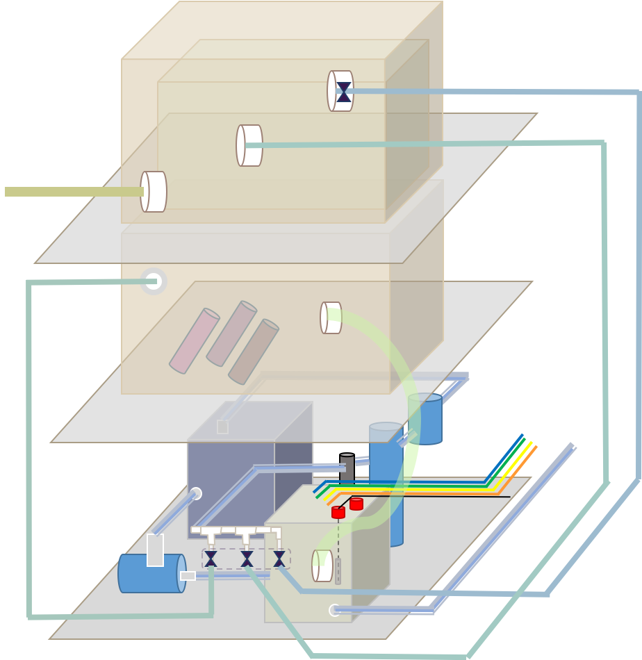

#### A.2 Collection: The September 9th, 2019 collection occurred at evening low tide, slack water, occurred at 2046. Nautical Twilight concluded at 2022, with Civil Twilight concluding at 1955. Sunset happened at 1932. Boat was launched at 1940. Boat on-station IVO 47.982569, -122.307623 at approximately 2030. 50meters of cable scope was deployed at a speed of 1.5-2knots to achieve a towing depth of approximately 25meters. Five of ten tows produced suitable sized krill ( x>.0250, x<.0650).

The September 10th, 2019 collection occurred at evening low tide, slack water, occurred at 2121. Nautical Twilight concluded at 2021, with Civil Twilight concluding at 1954. Sunset happened at 1931. Boat was launched at 2015. Boat on-station IVO 47.982569, -122.307623 at approximately 2100. Tows were similar in scope and duration to September 9th , 2019.

#### A.2.b Sorting:

09SEP19 25-krill were stocked between moats. 10SEP19 60 to 65-krill were stocked between MOATs to bring the project start totals to the MOATs as follows: MOATs 01- 85 | MOATs 02- 85 | MOATs 03- 80 | MOATs 04- 80 |  
MOATs 05- 80 | MOATs 06- 80 | MOATs 07- 80 | MOATs 08- 80 |  
MOATs 10- 80 | MOATs 11- 80 | MOATs 12- 80 | MOATs 13- 80 |

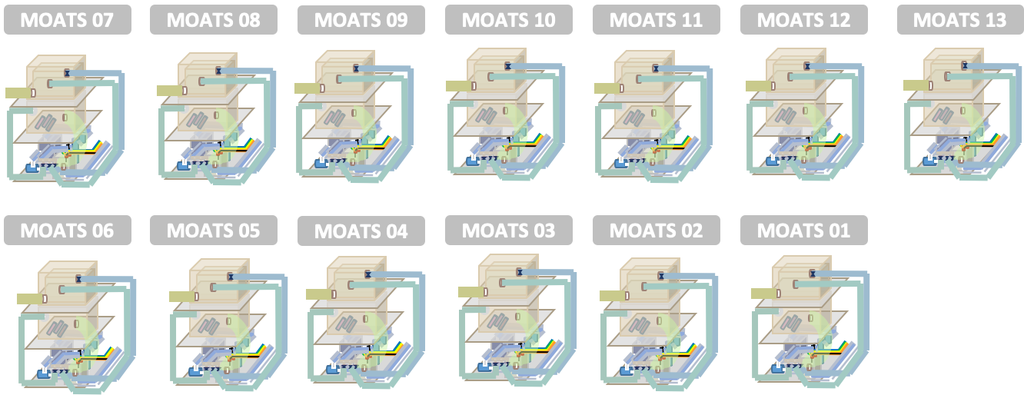

Graph 2: Replicate MOATS Lab Setup

#### A.2.c Initial Density:

Krill were held under acclimation conditions for 11-12 days and treatment conditions for 35-37 days. They were housed in 44L aquaria inside each replicate experimental treatment at an initial density of 80-85 krill per replicate (1.8 krill/L; ~ 3 g krill per replicate).

# B. Explanation of MOATs and Treatment Determination

#### B.1 Treatment Determination & Survival

Krill Treatment determinations were made approximately on 19SEP19 and confirmed on 24SEP19 with the introduction of the ambient treatment. The division shown below was aimed to start the experiment with survival divided equally among MOATS.

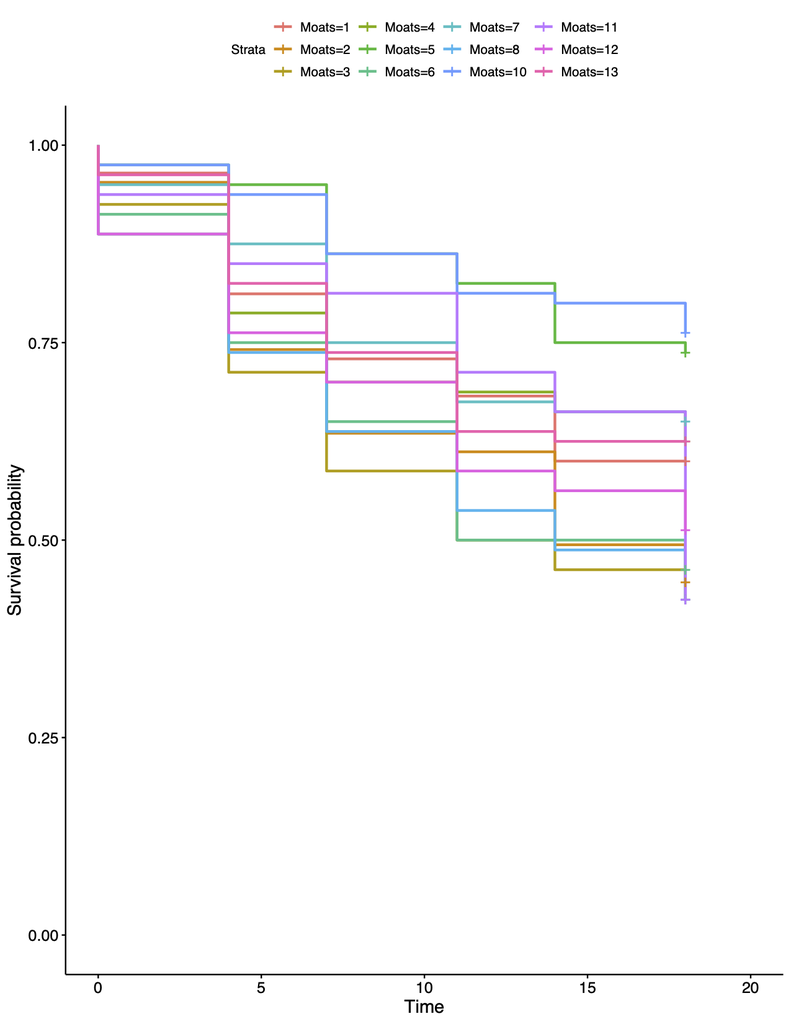

#### B.1a Inital Treatment Determinations Determinations on 19SEP19

“All Change” Conditions Treatment: M02, M05, M08, M13 “High Temperature” Conditions Treatment: M01, M04, M06, M11 “Current” Conditions Treatment: M03, M07, M10, M12

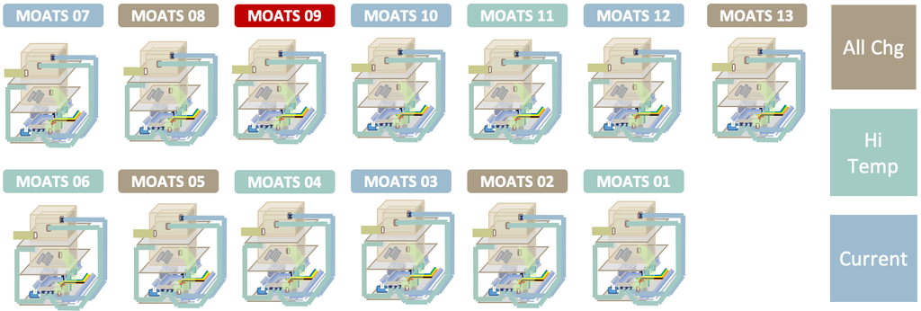

# 1. Setting the Working Directory

1.0 Look for all files inside the Water Chemistry folder of the “06. MOATs replication verification” folder

#### 1.1 Initial Working Directoy

Inside the working directory (folder) is 1 CSV files generated after combining 13CSV logs representing 24second observations. These CSV files were created using the moats graph app

#### 1.1.2 Link to Generating App

[Link to moats.Graph.app](http://github.com/pmcelhany/moatsGraphs.git) Moving average window (nObs) set to 4.

#### 1.1.3 Protocol with app

Every 17th observations was selected, the observations were 24second apart.

#### 1.1.4 App data for 13 MOATS

1 CSVs per moats: M01, M02, M03, M04, M05, M06, M07, M08, M09, M10, M11, M12, M13. Files are also available on the OA Google drive. [OA Drive for MOATS data](https://drive.google.com/open?id=13a2hk1a9I9gRIgf2Xyl1dSYDf5vnyYvs)

### 1.2 Subsampling

#### 1.2.1 Subsampling explained by observations

All observations (per the 13 MOATS logs) [1] 1137880 7 (6 seconds) Number of observations after subsampling every 17th response/observation [1] 66934 7 (24 seconds) Number of observations after the super-subsampling, every 333rd observation [1] 3417 7 (~30minutes) ***this won’t detail the ramp

#### 1.2.2 Subsampling Determination

To examine the Day to Night ramp (D2Nramp) researcher used n17 subsampling group

# 2.0) Calling and Reading in dml

```r
#*********************************
## 2. Calling & Reading in " dml "
#*********************************

# Super Speedy subsampled data
dml <- read.csv(file = "M01thruM13moatslog_n17.csv", stringsAsFactors = FALSE)
dim(dml)
```

# 3.0) Reformatting variables/vectors (Factors)

Changing MOATs to Factors for the 13 different MOATs- these will be the discrete units for follow analysis

```r
#*********************************
## 3. Reformatting variables/vectors (Factors)
#*********************************

## 3.3 Changing variables |
dml$moats <- factor(dml$moats)
# Checking the names of the different levels
levels(dml$moats)
##checking the dataset, dimensions
dim(dml)
```

# 4.0) Creating dateTime objects

Changes to the format of dates and times for observations

```r
dml$dateTime <- as.POSIXct(dml$dateTime, format="%Y-%m-%d %H:%M:%OS")
ReferenceTime <- as.POSIXct("2019-09-20 23:59:00")
class(ReferenceTime)

# QA check
dim(dml)
```

# 5.0) Creating Treatment Variables

#### 5.1 Three Treatments

Three treatments of this studies are identified as * “current” for the Current Conditions Treatment * “hightemperature” for the High Temperature Conditions Treatment * “allchange” for the All Change Conditions Treatment which incorporated both the high temperature conditions of the “hightemperature” treatment along with exposure to lower aquariun pH.

```r
## 5.1 Identifying treatments by moats
## establishing treatments
dml$treatment <- ""
dml$treatment[dml$moats == "M03" | dml$moats == "M07" | dml$moats== "M10" | dml$moats== "M12"] <- "current"
dml$treatment[dml$moats == "M01"| dml$moats== "M04"| dml$moats== "M06"| dml$moats== "M11"] <- "hightemperature"
dml$treatment[dml$moats == "M02"| dml$moats== "M05" | dml$moats== "M08" | dml$moats== "M13"] <- "allchange"
dml$treatment[dml$moats == "M09"] <- "broken"

dml$final_treatment <- ""
dml$final_treatment[dml$moats == "M07" | dml$moats== "M10" | dml$moats== "M12"] <- "current"
dml$final_treatment[dml$moats == "M01"| dml$moats== "M06"] <- "hightemperature"
dml$final_treatment[dml$moats == "M02"| dml$moats== "M08" | dml$moats== "M13"] <- "allchange"
dml$final_treatment[dml$moats == "M04" |dml$moats == "M05"]  <- "ambient"
dml$final_treatment[dml$moats == "M03"| dml$moats == "M09" | dml$moats== "M11"] <- "broken"
#verify that this new column has been created
names(dml)
#results should include:
#[1] "moats"        "dateTime"     "aTemperature" "sTemperature" "pH"
#[6] "DO"           "salinity"     "treatment"

# QA check
dim(dml)
```

#### 5.1.1 Ambient Treatment

Those MOATS aquarium systems that did not reach desired/programed conditions were deemed the “ambient” treatment. No temperature, DO, or pH conditions were programmed or alarmed. Flow control was governed by a solenoid valve to acheive flow/no-flow, day/night periods.

MOATS inside the “Ambient” treatment included MOATs 04 and MOATs 05 both were shown to have faulty thermisters.

Recorded conditions of what the animals experienced can’t be guaranteed/confirmed.

Without a record of aquarium settings MOATs 04 and MOAT 05 data was not included.

# 6.) Creating Night and Day Periods

#### 6.1 Narrative (Overall)

Creating a day and night variables Day and night periods will only refer to time under treatment as a way to exclude the acclimation period. Day and night changed at about ~ 1230 on 05OCT19 Treatment start date considered to begin Monday 23SEP19 at 1200pm Krill Night Starts 1200 (~1230*) and ends 2100 Krill Days Starts 2101 and ends 1159 (~1229*) Interval 1 start 1200 23SEP19, end 1229 05OCT19 Interval 2 start 1230 05OCT19, end 2100 30OCT19

#### 6.2 New Column, New Variable in dml

```r
## 6.2 New Column, New Variable in dml
#creating a new column, new variable "period"
dml$period <- ""
```

#### 6.3 Disassembling dateTime to create 2 new variables

```r
## 6.3 Disassembling dateTime to create 2 new variables
# Create new split date and time columns
dml$ObservationDate <- as.Date(dml$dateTime)
dml$ObservationTime <- format(as.POSIXct(dml$dateTime) ,format = "%H:%M:%S")
```

#### 6.4 Narrative about Intervals

Interval 1 Interval Date Start “2019-09-23” Interval Date End “2019-10-05” Day Start Time “21:01:00” Day End Time “11:29:00” Night Start Time “12:00:00” Night End Time “21:00:00” DaytoNight Ramp(D2N) “11:30:00” start DaytoNight Ramp(D2N) “11:59:00” stop Other Time

#### 6.5 Period Assignments

```r
## 6.5 Day / Night Assignments
# Using the "case_when" function in the tidyverse in the place of a loop
  dml <- dml %>% mutate (period=case_when(
  (ObservationDate >= "2019-09-23")
  & (ObservationDate <="2019-10-05")
  & (ObservationTime >= "12:00:00")
  & (ObservationTime <="21:00:00") ~"night",

  (ObservationDate >= "2019-10-05")
  & (ObservationDate <= "2019-10-30")
  & (ObservationTime >= "12:31:00")
  & (ObservationTime <="21:00:00") ~"night",

  (ObservationDate >= "2019-09-23")
  & (ObservationDate <="2019-10-05")
  & ((ObservationTime >= "21:01:00")
     | (ObservationTime <="11:29:00")) ~"day",

  (ObservationDate >= "2019-10-05")
  & (ObservationDate <= "2019-10-30")
  & ((ObservationTime >= "21:01:00")
     | (ObservationTime <= "12:01:00")) ~"day",

  (ObservationDate >= "2019-09-23")
  & (ObservationDate <="2019-10-05")
  & ((ObservationTime >= "11:30:00")
     | (ObservationTime <="12:00:00")) ~"D2Nramp",

  (ObservationDate >= "2019-10-05")
  & (ObservationDate <= "2019-10-30")
  & ((ObservationTime >= "12:01:00")
     | (ObservationTime <= "12:30:00")) ~"D2Nramp",


  TRUE ~"other"
)

)
```

#### 6.5.1 Quick Check on Period Generation

```r
#Quick check to see if periods were created

period.intervals <- ggplot(dml, aes(x=dateTime, y=aTemperature)) +
  geom_point(aes(colour=period, point=))   +
  ggtitle("aTemperature Time Series Plots to Invesitgate Different Intervals") +
  ylim (5.0, 15.00)

period.intervals
```

#### 6.5.1 Quick Check on Day to Night Ramp Verification

The ramp verification will be important to dissolved oxygen verification Dissolved oxygen not yet shown. Recorded dissolved oxygen needs to be corrected with observed salinity.

```r
ggplot(subset(dml,
               period %in% ("D2Nramp")),
        aes(x=dateTime, y=aTemperature)) +
   geom_point(aes(colour=treatment, point=)) +
   ylim (5.0, 15.00) +
   ggtitle("aTemperature Values, All MOATs, During Day to Night Ramp Period")
```

#### 6.6 Removing the Acclimation Period

The acclimation and the time after animals were removed from the system was designated other

```r
# Removing "other" period from day and night
# not including acclimation period in this investigation

H2Ochemdf <- dml %>% filter(period != "other")
```

# 7.) Bringing in Salinity

```r
knitr::opts_chunk$set(echo = TRUE)

knitr::opts_knit$set(root.dir =
                       "/Users/katherinerovinski/GIT/NWFSC.MUK_KRL_SMR2019/06_MOATS_replication_verification/01a_WaterChemistry_Data")

getwd()
setwd("/Users/katherinerovinski/GIT/NWFSC.MUK_KRL_SMR2019/06_MOATS_replication_verification/01a_WaterChemistry_Data")
getwd()




all_salinity <- read.csv(file = "KRL19_salinityreadings_all.csv", stringsAsFactors = FALSE)
all_salinity$PSU_ObsDate <- ""#

all_salinity$Date <- as.POSIXct(all_salinity$Date, format= "%m/%d/%y")
all_salinity$PSU_ObsDate <- as.Date(all_salinity$Date)
```